# Predicting Income Level from Demographic and Behavioral Factors

A Comparison of Linear Regression with an Indicator Matrix and Logistic Regression Approaches

Donnie Minnick

August 28, 2025

# Project Overview

This analysis evaluates two modeling approaches - linear regression with an indicator matrix and logistic regression - to determine which more reliably classifies individuals as earning above or below $50,000 per year. Using the UCI Adult Income dataset, the comparison focuses on practical performance measures including accuracy, sensitivity, specificity, and AUC.

The goal is to identify the method that not only provides stronger predictive capability but also offers clearer insight into how demographic and employment attributes influence income levels.

## Analysis Question

How do linear regression with an indicator matrix and logistic regression compare in their ability to classify individuals as earning above or below $50,000 per year, based on demographic and employment attributes from the UCI Adult Income dataset, in terms of accuracy, sensitivity, specificity, and AUC?

## Data Suitability

The [UCI Adult Income dataset](https://archive.ics.uci.edu/dataset/2/adult) is highly appropriate for this analysis because:

**Binary Target Variable**: The income label is already dichotomized as `<=50K` and `>50K`, making it ideal for classification tasks.

**Rich Feature Set**: It includes fourteen attributes spanning age, education, marital status, occupation, hours worked, and more, offering diverse predictors for modeling socioeconomic outcomes.

**Mixed Data Types**: The combination of categorical and continuous variables supports testing how each model handles encoding and feature interactions.

**Real-World Relevance**: The income threshold reflects a meaningful socioeconomic divide, making the classification task practically significant.

## Candidate Models

### Linear Regression with an Indicator Matrix

Linear regression, when applied with a binary indicator response, can be used to estimate probabilities of class membership. Although not traditionally designed for classification, it provides a straightforward benchmark and can reveal how continuous predictors like age or hours worked relate linearly to income. However, it may yield predictions outside the 0–1 range and does not naturally account for the probabilistic nature of binary outcomes.

### Logistic Regression

Logistic regression is a standard method for binary classification, modeling the log-odds of the outcome as a linear combination of predictors. It constrains predicted values between 0 and 1 and provides interpretable coefficients in terms of odds ratios. It is particularly well-suited for this problem and serves as the conventional baseline for evaluating newer or more complex classifiers.

### Why Compare?

Placing these two approaches side by side highlights the importance of choosing models that align with the data structure and research question. By comparing their performance on accuracy, sensitivity, specificity, and AUC, this analysis will demonstrate the trade-offs between a general-purpose regression method and a model purpose-built for classification.

### Baseline Expectations

Before conducting the analysis, it is important to establish expectations about how the candidate models are likely to perform:

**Logistic Regression Advantage**: Because logistic regression is specifically designed for binary classification, it is expected to outperform linear regression in terms of calibration and overall predictive reliability. Its ability to constrain predictions between 0 and 1 aligns naturally with the problem structure.

**Linear Regression Benchmark**: Linear regression with an indicator matrix may provide a useful baseline, but its predictions can extend outside the valid probability range and may not align as well with classification thresholds. Accuracy may be reasonable, but sensitivity and specificity are likely to suffer compared to logistic regression.

**Comparative Outlook**: Logistic regression is anticipated to deliver higher AUC and more balanced classification metrics, while linear regression may illustrate the pitfalls of applying a general-purpose model to a classification task. This contrast should highlight the importance of model choice in predictive analytics.

## Github Repo

## Code Libraries

The analysis leverages the following R packages: `caret` for model training and evaluation, `dplyr` for data manipulation, `knitr` for report formatting, and `pROC` for ROC/AUC analysis.

# Data Cleaning and Transformation

```r
income <- readRDS("../data/income.rds")
```

## Missing Values

## Redundancy

## Transformations

## Class Balance

We kept the natural 75/25 income split so predictions mirror real-world conditions. This ensures performance metrics are meaningful for decision-making, while still allowing models to be tuned for sensitivity and accuracy where it matters most.

# Split Data

The dataset is split into 60% training, 20% validation, and 20% test. This allocation provides enough data to train stable models while dedicating a higher-than-usual share to validation and testing. With a large dataset, this approach strengthens model comparison, improves tuning, and ensures that final performance metrics are based on a robust and representative holdout set.

To preserve representativeness, the data is split using stratified sampling so that the proportion of individuals earning `≤50K` and `>50K` remain consistent across the training, validation, and test sets.

```r
set.seed(123)

# Initial train/test split.

train_idx <- createDataPartition(income$income_below_num, p = 0.6, list = FALSE)

train <- income[train_idx, ]

temp  <- income[-train_idx, ]

# Split remaining into validation/test.

valid_idx <- createDataPartition(temp$income_below_num, p = 0.5, list = FALSE)

validation <- temp[valid_idx, ]

test <- temp[-valid_idx, ]
```

Check class balance.

```r
check_balance <- function(df, name) {
  df %>%
    count(income_below_num) %>%
    mutate(prop = round(n / sum(n), 2),
           dataset = name) %>%
    select(dataset,
           income_below_num,
           n,
           prop)
}

check <- bind_rows(check_balance(train, "Train"),
                   check_balance(validation, "Validation"),
                   check_balance(test, "Test"))

kable(check,
      col.names = c("Dataset", "Income Level", "Count", "Percent"),
      caption = "Dataset Class Balance",
      format.args = list(big.mark = ","),
      align = c("l", "r", "r", "r"))
```

Dataset Class Balance

| Dataset | Income Level | Count | Percent |
| --- | --- | --- | --- |
| Train | 0 | 4,500 | 0.25 |
| Train | 1 | 13,597 | 0.75 |
| Validation | 0 | 1,571 | 0.26 |
| Validation | 1 | 4,461 | 0.74 |
| Test | 0 | 1,437 | 0.24 |
| Test | 1 | 4,595 | 0.76 |

# Train Models

## Linear Regression Indicator Matrix Model

```r
# Step 1: Prepare predictor matrix
X <- as.matrix(train[, c("age_num", "education_num", "marital_status_num")])

# Step 2: Create indicator matrix for binary response
G <- train$income_num  # Assumed to be 0/1
Y <- model.matrix(~ factor(G) - 1)  # One-hot encoding

# Step 3: Fit multivariate linear regression
fit <- lm(Y ~ X)

# Step 4: Predict class scores
pred <- predict(fit, newdata = data.frame(X))

# Step 5: Assign predicted class (1 or 2)
class_pred <- max.col(pred)

# Step 6: Recode predicted class to match binary response (0/1)
class_pred_binary <- ifelse(class_pred == 1, 0, 1)

# Step 7: Evaluate classification performance
conf_mat <- caret::confusionMatrix(
  factor(class_pred_binary),
  factor(train$income_num)
)

# Step 8: Print metrics
conf_mat$overall["Accuracy"]
```

```
##  Accuracy
## 0.7726695
```

```r
conf_mat$byClass[c("Sensitivity", "Specificity", "Precision")]
```

```
## Sensitivity Specificity   Precision
##   0.9546223   0.2228889   0.7877648
```

### Extreme Probabilities

The table below summarizes the number and percentage of predicted probabilities from the linear regression model that fall outside the valid 0–1 range for each class. As expected, linear regression applied to a binary outcome can produce estimates below 0 or above 1, highlighting a limitation of this approach for classification tasks.

```r
# Extract columns
prob_under50k <- pred[, "factor(G)0"]
prob_over50k  <- pred[, "factor(G)1"]

# Count out-of-bounds for each class
out_under <- sum(prob_under50k < 0 | prob_under50k > 1)
out_over  <- sum(prob_over50k  < 0 | prob_over50k  > 1)
total <- nrow(pred)

# Summary table
data.frame(
  Class = c("<=50K", ">50K"),
  Out_of_Bounds = c(out_under, out_over),
  Total = total,
  Percent_Out_of_Bounds = round(100 * c(out_under, out_over) / total, 2)
)
```

| Class | Out_of_Bounds | Total | Percent_Out_of_Bounds |
| --- | --- | --- | --- |
| <=50K | 1252 | 18097 | 6.92 |
| >50K | 1252 | 18097 | 6.92 |

```r
# kable(check,
#       col.names = c("Dataset", "Income Level", "Count", "Percent"),
#       caption = "Dataset Class Balance",
#       format.args = list(big.mark = ","),
#       align = c("l", "r", "r", "r"))
```

The plot below illustrates the distribution of predicted probabilities for both income classes. The dashed red lines mark the valid 0–1 probability range. Any predictions beyond these boundaries are not interpretable as probabilities, demonstrating why logistic regression is generally preferred for binary classification problems.

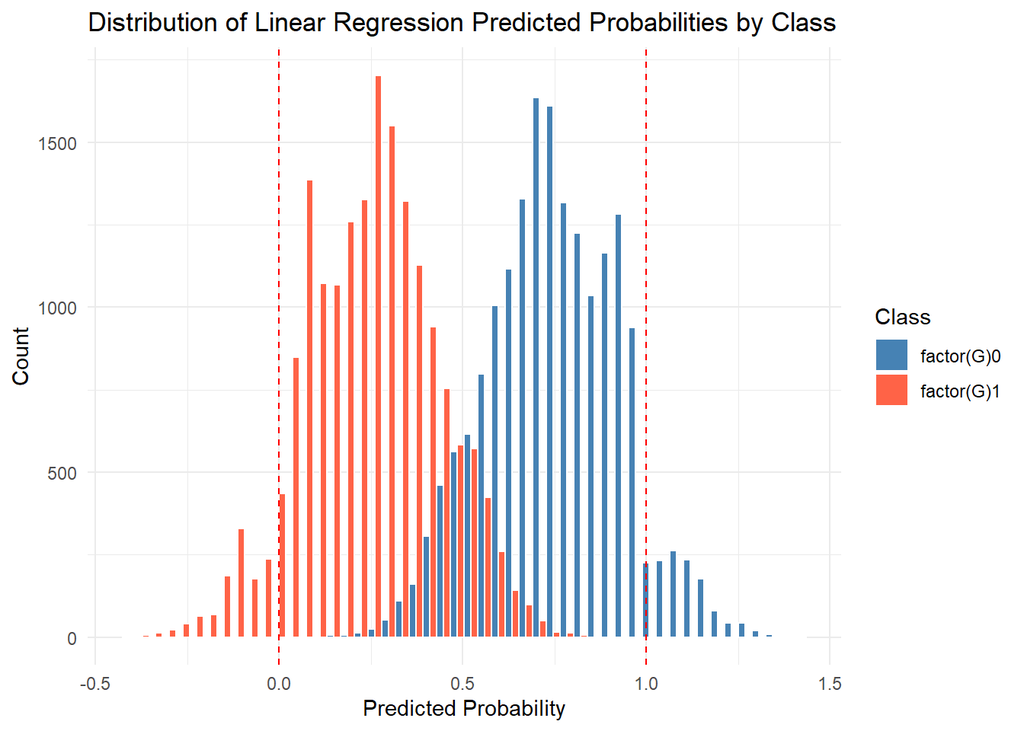

```r
# Convert to long format for ggplot
df_long <- as.data.frame(pred) %>%
  pivot_longer(cols = everything(), names_to = "Class", values_to = "Probability")

# Plot
ggplot(df_long, aes(x = Probability, fill = Class)) +
  geom_histogram(bins = 50, color = "white", position = "dodge") +
  geom_vline(xintercept = 0, linetype = "dashed", color = "red") +
  geom_vline(xintercept = 1, linetype = "dashed", color = "red") +
  labs(
    x = "Predicted Probability",
    y = "Count",
    title = "Distribution of Linear Regression Predicted Probabilities by Class"
  ) +
  scale_fill_manual(values = c("factor(G)0" = "steelblue", "factor(G)1" = "tomato")) +
  theme_minimal()
```

Together, these outputs provide a numeric indication and clear visual of the constraints of using linear regression for a categorical outcome, setting the stage for comparison with the logistic regression model.

### Generate ROC Curve and AUC Metric

```r
# Column 2 corresponds to class 1 (income_num == 1)
score_class1 <- pred[, 2]

roc_obj <- pROC::roc(response = train$income_num, predictor = score_class1)
```

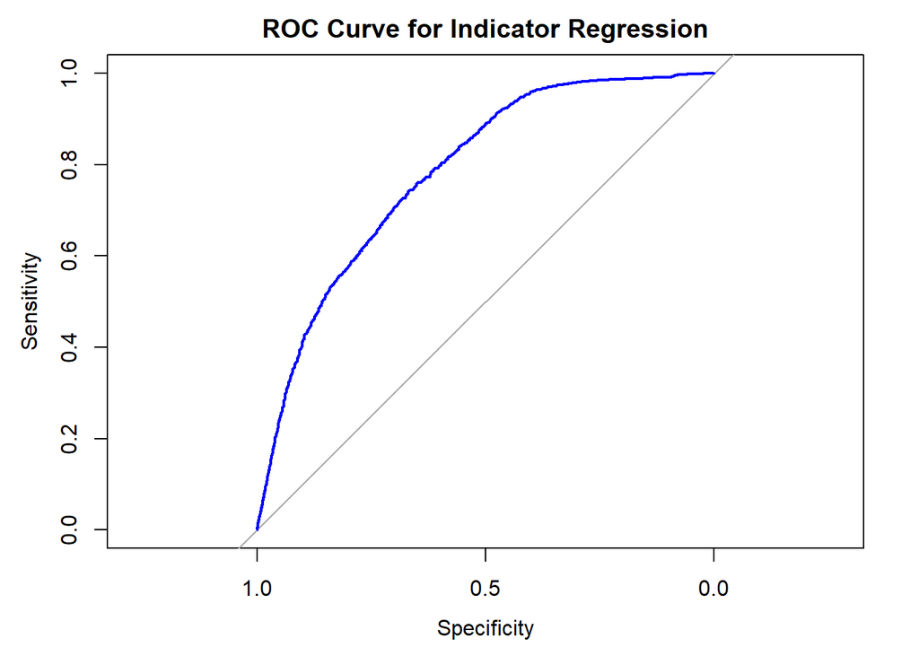

```r
# Plot ROC curve
plot(roc_obj, col = "blue", lwd = 2, main = "ROC Curve for Indicator Regression")
```

```r
# AUC value
auc_value <- pROC::auc(roc_obj)
print(auc_value)
```

```
## Area under the curve: 0.7841
```

## Logistic Regression

```r
model_logistic <- glm(income_num ~
                        age_num +
                        #workclass_num +
                        education_num +
                        marital_status_num,
                        #hours_per_week_num +
                        #relationship_num +
                        #race_num +
                        #gender_num +
                        #capital_gain_num +
                        #capital_loss_num,
                      data = train, family = "binomial")
```

### Generate Model Summary

```r
summary(model_logistic)
```

```
##
## Call:
## glm(formula = income_num ~ age_num + education_num + marital_status_num,
##     family = "binomial", data = train)
##
## Coefficients:
##                     Estimate Std. Error z value Pr(>|z|)
## (Intercept)        -5.702500   0.130576  -43.67   <2e-16 ***
## age_num             0.039673   0.001587   25.00   <2e-16 ***
## education_num       0.363727   0.008670   41.95   <2e-16 ***
## marital_status_num -0.253495   0.013428  -18.88   <2e-16 ***
## ---
## Signif. codes:  0 '***' 0.001 '**' 0.01 '*' 0.05 '.' 0.1 ' ' 1
##
## (Dispersion parameter for binomial family taken to be 1)
##
##     Null deviance: 20300  on 18096  degrees of freedom
## Residual deviance: 16756  on 18093  degrees of freedom
## AIC: 16764
##
## Number of Fisher Scoring iterations: 5
```

### Generate ROC Curve and AUC Metric

```r
train$predicted_prob <- predict(model_logistic, type = "response")

roc_obj <- pROC::roc(train$income_num, train$predicted_prob)
```

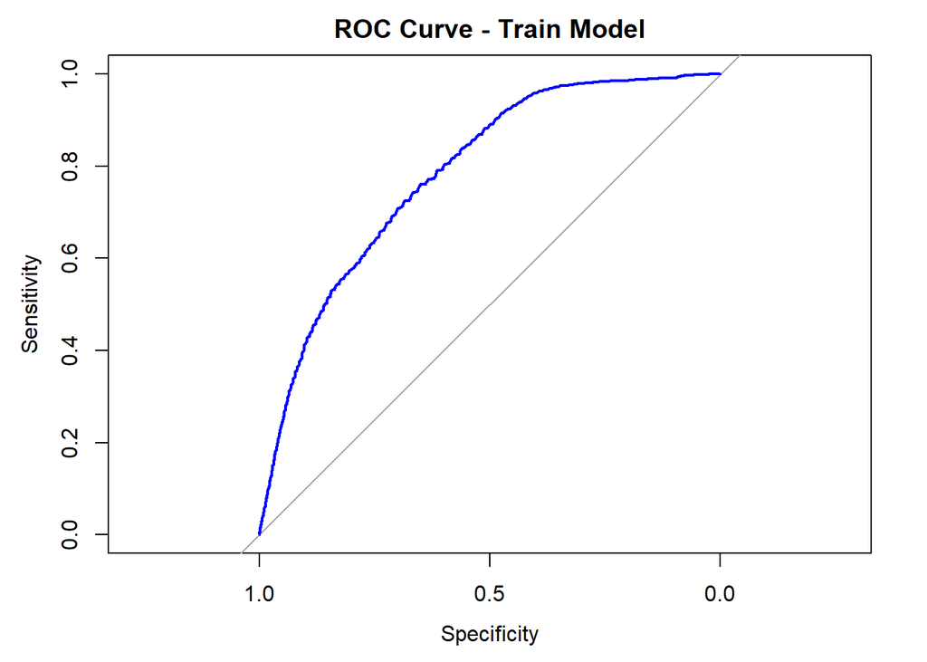

```r
plot(roc_obj, col = "blue", main = "ROC Curve - Train Model")
```

```r
pROC::auc(roc_obj)
```

```
## Area under the curve: 0.7842
```

### Generate Confusion Matrix

```r
threshold <- 0.5

train$predicted_class <- ifelse(train$predicted_prob > 0.5, 1, 0)
```

```r
caret::confusionMatrix(factor(train$predicted_class), factor(train$income_num))
```

```
## Confusion Matrix and Statistics
##
##           Reference
## Prediction     0     1
##          0 12707  3094
##          1   890  1406
##
##                Accuracy : 0.7799
##                  95% CI : (0.7737, 0.7859)
##     No Information Rate : 0.7513
##     P-Value [Acc > NIR] : < 2.2e-16
##
##                   Kappa : 0.2954
##
##  Mcnemar's Test P-Value : < 2.2e-16
##
##             Sensitivity : 0.9345
##             Specificity : 0.3124
##          Pos Pred Value : 0.8042
##          Neg Pred Value : 0.6124
##              Prevalence : 0.7513
##          Detection Rate : 0.7022
##    Detection Prevalence : 0.8731
##       Balanced Accuracy : 0.6235
##
##        'Positive' Class : 0
##
```

```r
confusion <- table(Predicted = train$predicted_class,
                   Actual = train$income_num)

TP <- confusion[2, 2]
FP <- confusion[2, 1]
FN <- confusion[1, 2]
TN <- confusion[1, 1]

sensitivity <- TP / (TP + FN)
specificity <- TN / (TN + FP)
accuracy <- (TP + TN) / sum(confusion)

list(confusion = confusion,
     sensitivity = round(sensitivity, 2),
     specificity = round(specificity, 2),
     accuracy = round(accuracy, 2))
```

```
## $confusion
##          Actual
## Predicted     0     1
##         0 12707  3094
##         1   890  1406
##
## $sensitivity
## [1] 0.31
##
## $specificity
## [1] 0.93
##
## $accuracy
## [1] 0.78
```

# Compare Models

## Training Data

## Validation Data

# Choose Final Model

# Retrain Final Model

# Evaluate Model

# Final Analysis

## Conclusions

## Challenges and Solutions